# Part II - Prosper Loan Data Information

## by Jonathan Ravel

## Investigation Overview

> In this exploration I show the rapid growth of Prosper from 2010 to 2013. Borrowers were very interested in their signature product!

> Yet the rates the borrowers paid varied greatly - some paid under 10% APR (Annual Percentage Rate), while others paid more than 35%.

## Dataset Overview

> Loan data from Prosper from 2005 to 2014 that had data on 113,937 loans with 81 variables.

## Visualization 1

> Prosper grew rapidly after the Great Financial Crisis, especially from 2010 to 2013. Total loans increased at a rapid pace.

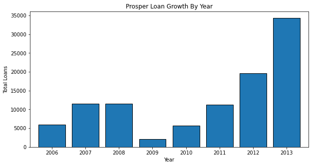

## Visualization 2

> The rates borrowers were paying for these period loans varied greatly, from under 10% to over 35%!

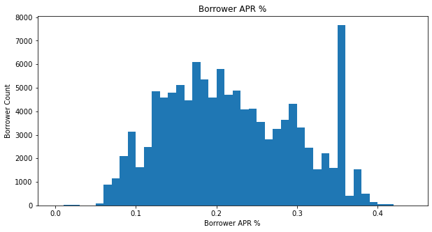

## Visualization 3

> Prosper assigned ratings to these borrowers, which reflected their idea of the best borrowers (Rating 7) who paid the lowest rates, and the most risky borrowers (Rating 1), who paid the highest rates.

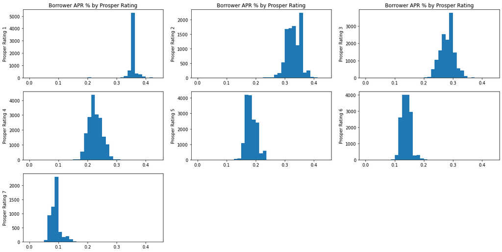

## Visualization 4

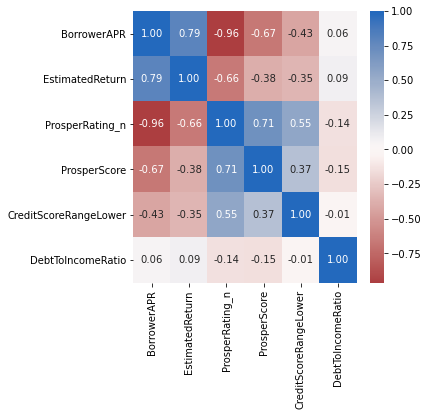

> This means Prosper was using measures other than Credit Score to underwrite their borrowers!